# Instalação do R e RStudio

O R está diponível para os sistemas operacionais Linux, Mac e Windows. Aqui descreveremos os passos necessários para instalação em cada um deles. Caso enfrente problemas em alguma das etapas, verifique também as instruções no [site do CRAN](https://cran.r-project.org/). Se mesmo assim tiver problemas, entre em contato conosco pelo e-mail gent.esalq@gmail.com.

## Instalação do R no Ubuntu

Aqui consideraremos as distribuições Ubuntu LTS (Long Term Support), mas no [site do CRAN](https://cran.r-project.org/) você encontrará instruções também para debian, redhat e suse.

O primeiro passo para a instalação é procurar pelo arquivo `sources.list` e adicionar à ele o caminho para o “espelho” do R de sua preferência (veja as opções [aqui](https://cran.r-project.org/mirrors.html)) e a distribuição Linux referente ao seu sistema. Normalmente, o arquivo esta localizado em:

```bash
cd /etc/apt/
```

Pode ser que o arquivo esteja com permissão apenas para leitura para os usuários comuns, portanto acesse-o como super usuário utilizando um editor de texto de sua preferência e adicione o caminho. Exemplo:

```bash
sudo nano sources.list
```

Aqui consideraremos a distribuição Ubuntu Xenial Xerus (16.04) e escolheremos o espelho localizado na ESALQ, portanto adicionamos a linha:

```
#deb https://brieger.esalq.usp.br/CRAN/bin/linux/ubuntu xenial/
```

Se esta com dúvida qual é a distribuição que esta esta usando, utilize o comando para descobrir:

```bash
lsb_release -a
```

A partir disso basta seguir os comandos:

```bash
sudo update
sudo apt-get install r-base
sudo apt-get install r-base-dev
```

Você pode abrir o R pela linha de comando ou clicando no icone, fazendo isso você verá algo como:

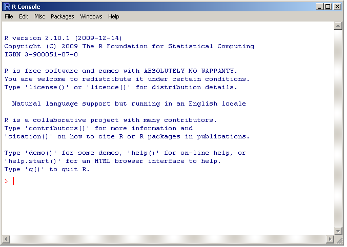

## Instalação do R no Windows

Faça o download do executável do R versão 3.6 contido neste [link](https://cran.r-project.org/bin/windows/base/). Clique duas vezes no arquivo .exe e siga as instruções do instalador.

Após terminar, clicando no icone do R você verá uma janela semelhante a figura 1.

## Instalação do R no MAC

Faça o download do executável do R versão 3.6 contido neste [link](https://cran.r-project.org/bin/macosx/R-3.6.0.pkg). Esta versão é compatível com as distribuições Mac OS X 10.6 ou superiores. Clique duas vezes no arquivo .pkg e siga as instruções do instalador.

Após terminar, clicando no icone do R você verá uma janela semelhante a figura 1.

## Instalação do RStudio

O RStudio é uma interface mais amigável do R, com funcionalidades muito práticas. A interface do RStudio também esta disponível para os sistemas Windows, Mac e Linux. Para qualquer um deles, selecione o arquivo correspondente no [site](https://www.rstudio.com/products/rstudio/download/).

No caso de um sistema linux, o arquivo baixado terá extenção `.deb`(para Ubuntu) ou `.rpm`(para Fedora) e basta clicar duas vezes no arquivo que o gerenciador de pacotes do Linux iniciará a instalação.

[GENt](https://gent-esalq.github.io/)  
Escola Superior de Agricultura Luiz de Queiroz  
Universidade de São Paulo

2019-05-15